# STAT-627 Assignment 4

Yunting Chiu

2021-06-16

In this assignment, I will be using [Tidymodels](https://www.tidymodels.org/) framework instead of base R.

# 1 Exercise 1 (10 points)

Explain the assumptions we are making when performing Principle Component Analysis (PCA). What happens when these assumptions are violated?

- *Sampling adequacy*: Large enough sample data are required to perform PCA. Otherwise, PCA can’t be correctly performed.
- *Data type*: Only continuous variables and some ordinal variables are suitable for PCA. If a variable is categorical and does not have proper ordinal variables, PCA can’t work.
- *Linearity*: It is assumed that the relationship between variables are linearly related. If it is violated, PCA can’t find the best fitting components.
- *No outliers*: PCA is sensitive to outliers. If there exist outliers, PCA may misjudge the components.
- *Correlation*: There should be some correlation among the factors. If this is violated, the data set if not suitable for dimension reduction.

# 2 Exercise 2 (10 points)

Answer the following questions regarding Principle Component Analysis.

- Is it important to standardize before applying PCA?

Ans: Yes. One assumption of PCA is that we assume that each of the variables in the data set has been centered to have mean zero so it is important to standardize the data set before applying PCA.

- Should one remove highly correlated variables before doing PCA?

Ans: No. Because PCA is an unsupervised learning technique, and it is for exploratory data analysis. There is no need to remove highly correlated variables. We only need to make sure that the new components are uncorrelated with the preceding components (e.g. $Z_2$ uncorrelated with $Z_1$).

- What will happen when eigenvalues are roughly equal?

Ans: The variances of the components are the eigenvalues. If eigenvalues are roughly equal, it means that the variances of the variables are roughly equal. In that case, the reduction of the data set via PCA into a smaller dimensional subspace might NOT be ideal since it is hard to distinguish “more informative” components (e.g. the variable that accounts for the most variation in the data set).

- Can PCA be used to reduce the dimensionality of a highly nonlinear data set?

Ans: PCA works better for linear data because one of its assumptions is that it assumes the data set to be linear combinations of the variables. However, some techniques can be applied for nonlinear PCA.

# 3 Exercise 3 (10 points)

You will in this exercise explore a data set using PCA. The data comes from the [#tidytuesday project](https://github.com/rfordatascience/tidytuesday) and is about [Student Loan Payments](https://github.com/rfordatascience/tidytuesday/tree/master/data/2019/2019-11-26).

Load in the data using the following script.

```r
loans <- readr::read_csv("https://raw.githubusercontent.com/rfordatascience/tidytuesday/master/data/2019/2019-11-26/loans.csv") %>%
  select(-agency_name, -added) %>%
  drop_na()
```

1. Use the `prcomp()` function to perform PCA on the loans data set. Set `scale. = TRUE` to perform scaling. What results are contained in this object? (hint: use the `names()` function)

`loans` data set has the following variables

```r
names(loans)
```

```
## [1] "year"               "quarter"            "starting"
## [4] "total"              "consolidation"      "rehabilitation"
## [7] "voluntary_payments" "wage_garnishments"
```

Make sure we need to remove all non-numeric columns in advance. Sure, we can go ahead.

```r
str(loans)
```

```
## tibble [278 × 8] (S3: tbl_df/tbl/data.frame)
##  $ year              : num [1:278] 15 15 15 15 15 15 15 15 15 15 ...
##  $ quarter           : num [1:278] 4 4 4 4 4 4 4 4 4 4 ...
##  $ starting          : num [1:278] 5.81e+09 3.69e+09 2.36e+09 7.04e+08 2.95e+09 ...
##  $ total             : num [1:278] 1.23e+08 1.13e+08 8.39e+07 9.96e+07 7.57e+07 ...
##  $ consolidation     : num [1:278] 20081894 11533809 7377703 3401361 8946976 ...
##  $ rehabilitation    : num [1:278] 90952573 86967994 64227391 85960328 58395653 ...
##  $ voluntary_payments: num [1:278] 5485507 4885225 3939866 2509000 2909013 ...
##  $ wage_garnishments : num [1:278] 6082668 9939819 8308043 7773214 5473844 ...
```

## 3.1 Principal Component Analysis

Performing PCA on the `loans` data set

```r
loans_pca <- prcomp(~., data = loans, scale. = TRUE)
loans_pca
```

```
## Standard deviations (1, .., p=8):
## [1] 2.280109e+00 1.092617e+00 8.806929e-01 7.109859e-01 4.911129e-01
## [6] 2.298129e-01 1.793515e-01 3.283268e-16
##
## Rotation (n x k) = (8 x 8):
##                           PC1          PC2         PC3         PC4         PC5
## year               0.15481630 -0.609154282  0.71098192  0.25713986 -0.16708786
## quarter            0.03100797  0.786863976  0.52892399  0.24341051 -0.19005106
## starting           0.43098287  0.020871379  0.04127974 -0.09648700 -0.00345036
## total              0.42241658  0.007288533 -0.21562217  0.06348967 -0.36946649
## consolidation      0.38135985  0.049807680  0.18110377 -0.60881252  0.21861788
## rehabilitation     0.40387031 -0.005538468 -0.28934855  0.13556608 -0.56400604
## voluntary_payments 0.41562996  0.079102751  0.13888702 -0.21645279  0.29164295
## wage_garnishments  0.35999109  0.022774599 -0.17531809  0.65223239  0.59033267
##                             PC6         PC7           PC8
## year                0.008145368  0.07322624  5.460575e-17
## quarter             0.046285326  0.05111353  2.013611e-16
## starting            0.307381188 -0.84161113 -4.778782e-17
## total              -0.010590898  0.19628903 -7.719069e-01
## consolidation       0.445114306  0.43687990  1.088487e-01
## rehabilitation     -0.068857583  0.15411095  6.230273e-01
## voluntary_payments -0.816160793 -0.05285133  2.976180e-02
## wage_garnishments   0.184957853  0.16667081  5.712260e-02
```

2. Calculate the amount of variance explained by each principal component. (hint: look at `?broom::tidy.prcomp`)

Standard deviation = square root of the variance, so the variance by each principal component will be:

```r
loans_pca %>%
  tidy(matrix = "pcs") %>%
  mutate(Variance = (std.dev)^2) %>%
  select(PC, Variance)
```

```
## # A tibble: 8 x 2
##      PC Variance
##   <dbl>    <dbl>
## 1     1 5.20e+ 0
## 2     2 1.19e+ 0
## 3     3 7.76e- 1
## 4     4 5.06e- 1
## 5     5 2.41e- 1
## 6     6 5.28e- 2
## 7     7 3.22e- 2
## 8     8 1.08e-31
```

3. Use the `tidy()` function to extract the **loadings**. Which variable contributed most to the first principle component? Second Component?
- `starting` contributes the most in PC1.
- `quarter` contributes the most in PC2.

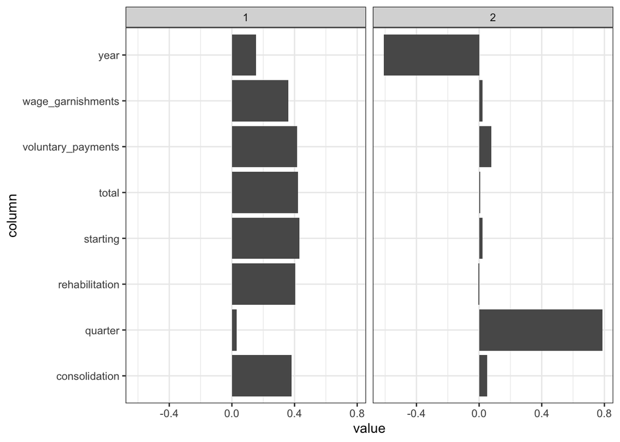

```r
loans_pca %>%
  tidy(matrix = "loadings") %>%
  filter(PC == 1 | PC == 2) %>%
  ggplot(aes(value, column)) +
  geom_col() +
  facet_wrap(~PC) +
  theme_bw()
```

4. Use the `augment()` function to get back the transformation and create a scatter plot of any two components of your choice.

The fitted PC1 against PC2 coordinates for each quarter of the year are shown below.

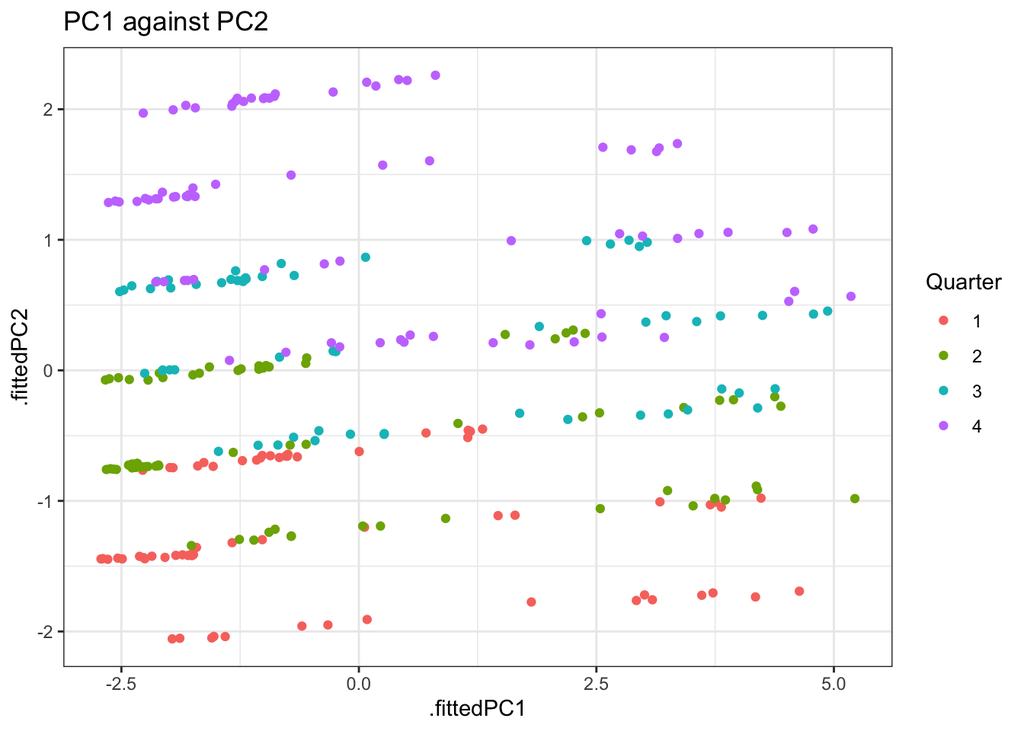

```r
augment(loans_pca, newdata = loans) %>%
  ggplot(aes(x = .fittedPC1, y = .fittedPC2, color = factor(quarter))) +
  geom_point() +
  theme_bw() +
  labs(color = "Quarter") +
  ggtitle("PC1 against PC2")
```

# 4 Exercise 4 (15 points)

In this exercise, you are tasked to predict the weight of an animal in a zoo, based on which words are used to describe it. The `animals` data set can be downloaded here.

Read the data set. We can see there are 801 variables with 479 observations!!!

```r
animals <- read_csv("./data/animals.csv") %>%
  filter(!is.na(weight))
dim(animals)
```

```
## [1] 479 801
```

```r
# str(animals) # all variables are numerical
```

This data set contains 801 variables. The first variable `weight` is the natural log of the mean weight of the animal. The remaining variables are named `tf_*` which shows how many times the word `*` appears in the description of the animal.

Use {tidymodels} to set up a workflow to train a PC regression. We can do this by specifying a **linear regression model**, and create a preprocessor recipe with {recipes} that applies PCA transformation on the predictors using `step_pca()`. Use the `threshold` argument in `step_pca()` to only keep the principal components that explain 90% of the variance.

Setting a seed and splitting the data to the training and testing sets

```r
set.seed(1234)
animals_split <- initial_split(animals, strata = "weight")
animals_train <- training(animals_split)
animals_test <- testing(animals_split)
```

Customize a recipe for the question

```r
rec_spec <- recipe(weight ~., data = animals_train) %>%
  step_normalize(all_predictors()) %>%
  step_pca(all_predictors(), threshold = 0.9)
rec_spec
```

```
## Data Recipe
##
## Inputs:
##
##       role #variables
##    outcome          1
##  predictor        800
##
## Operations:
##
## Centering and scaling for all_predictors()
## No PCA components were extracted.
```

Construct a linear regression specification

```r
lm_spec <- linear_reg() %>%
  set_mode("regression") %>%
  set_engine("lm")
lm_spec
```

```
## Linear Regression Model Specification (regression)
##
## Computational engine: lm
```

Construct the model workflow

```r
pcr_wf <- workflow() %>%
  add_recipe(rec_spec) %>%
  add_model(lm_spec)
pcr_wf
```

```
## ══ Workflow ════════════════════════════════════════════════════════════════════
## Preprocessor: Recipe
## Model: linear_reg()
##
## ── Preprocessor ────────────────────────────────────────────────────────────────
## 2 Recipe Steps
##
## • step_normalize()
## • step_pca()
##
## ── Model ───────────────────────────────────────────────────────────────────────
## Linear Regression Model Specification (regression)
##
## Computational engine: lm
```

## 4.1 Model Fitting

Fit the model

```r
pcr_fit <- fit(pcr_wf, data = animals_train)
```

How well does this model perform on the testing data set?

Lower value of RMSE indicates a better fit. In the initial stage, we want to keep the principal components that explain 90% of the variance so we set `threshold = 0.9` in `step_pca()`. The algorithm will generate enough components to capture 90 % of the variability in the variables. Because we have 90% variables, the rmse will be small when compared to `threshold = 0.1`.

```r
augment(pcr_fit, new_data = animals_test) %>%
  rmse(truth = weight, estimate = .pred) # root mean squared error
```

```
## # A tibble: 1 x 3
##   .metric .estimator .estimate
##   <chr>   <chr>          <dbl>
## 1 rmse    standard        2.67
```

## 4.2 Visualization

Because Principal Component Analysis is a linear method, the blue line can help us read the plot more easily. As of now, the `animals` data set contains 800 predictors, and PCR is effective at reducing the dimensionality of large data sets. However, the plot indicates the PCR model doesn’t have a good fit.

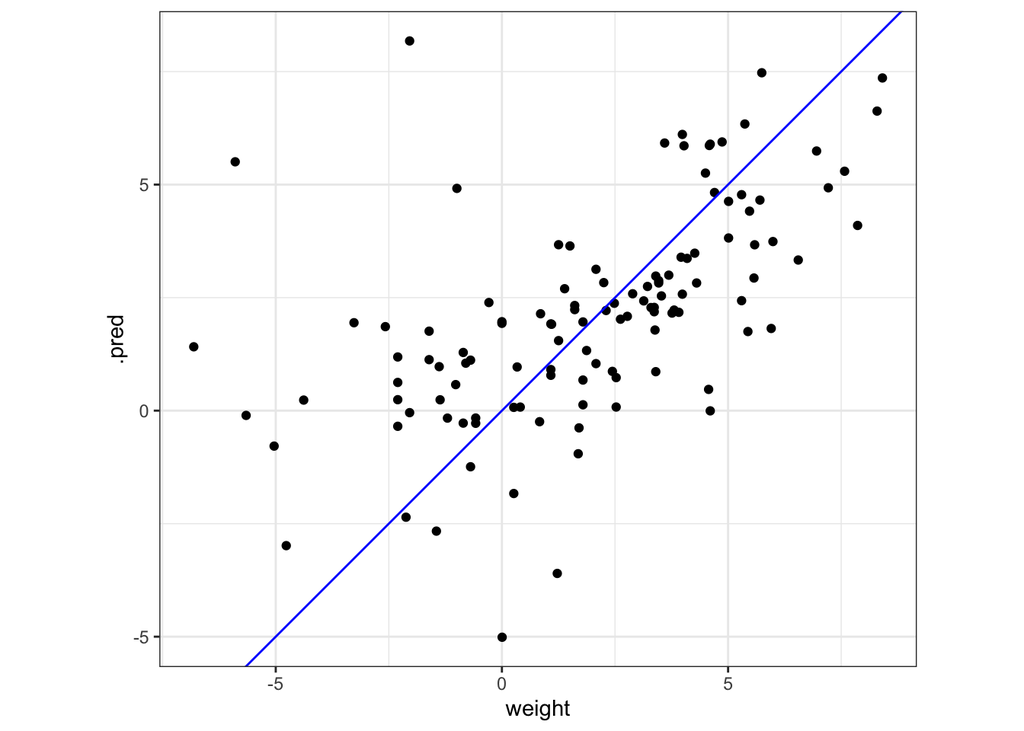

```r
augment(pcr_fit, new_data = animals_test) %>%
  ggplot(aes(weight, .pred)) +
  geom_point() +
  geom_abline(slope = 1, intercept = 0, color = "blue") +
  coord_fixed() +
  theme_bw()
```

# 5 Exercise 5 (10 points)

For part (a) through (c) indicate which of the statements are correct. Justify your answers.

1. The lasso, relative to least squares, is:
   1. More flexible and hence will give improved prediction accuracy when its increase in bias is less than its decrease in variance.
   2. More flexible and hence will give improved prediction accuracy when its increase in variance is less than its decrease in bias.
   3. Less flexible and hence will give improved prediction accuracy when its increase in bias is less than its decrease in variance.
   4. Less flexible and hence will give improved prediction accuracy when its increase in variance is less than its decrease in bias.

## 5.1 The lasso (L1 Regularization), relative to least squares is

**3** is correct. Compared to least squares models, the lasso is a restrictive model. Lasso regression can shrunk coefficients to 0 exactly (unless $\lambda = \infty$). In comparison to least squares, it penalizes the coefficients of non-essential variables to produce a model with a lower variance and higher bias.

## 5.2 The ridge (L2 Regularization), relative to least squares is

2. Repeat (a) for ridge regression relative to least squares.

**3** is correct. Because coefficients tend towards zero, variance decreases and bias increases, causing ridge regression less flexible than least squares regression. As the coefficient estimates shrink, we can obtain a relatively better MSE in ridge regression. The least squares coefficient results in a larger variance value. Ridge regression, on the other hand, can still perform well by trading off a increase in bias and reduce in variance.

## 5.3 The non-linear methods, relative to least squares is

3. Repeat (a) for non-linear methods relative to least squares.

**2** is correct. Non-linear models have more flexibility and less bias than least squares models. Non-linear models perform better when the linearity assumption is violated. Due to Non-linear models more sensitive fits to the underlying data, these approaches will have higher variation and will require a substantial reduction in bias to work well.

# 6 Exercise 6 (10 points)

Suppose we estimate the regression coefficients in a linear regression model by minimizing
$$\sum_{i=1}^n \left( y_i - \beta_0 - \sum^p_{j=1}\beta_j x_{ij} \right)^2 + \lambda \sum_{j=1}^p \beta_j^2$$

for a particular value of $\lambda$. For part (a) through (c) indicate which of the statements are correct. Justify your answers.

1. As we increase $\lambda$ from 0, the training RSS will:
   - Increase initially, and then eventually start decreasing in an inverted U shape.
   - Decrease initially, and then eventually start increasing in a U shape.
   - Steadily increase.
   - Steadily decrease.
   - Remain constant.

As we increase $\lambda$ from 0, the impact of the shrinkage penalty grows, meaning that we want smaller and smaller ridge regression coefficients in order to achieve the objection of minimization. This puts more and more restrictions on the coefficients. Therefore the training RSS will steadily increase.

2. Repeat (a) for test RSS.

As we increase $\lambda$ from 0, the test RSS will decrease initially and increase following a U shape.

3. Repeat (a) for variance.

As we increase $\lambda$ from 0, for the same reason, the model is becoming less and less flexible, meaning that the coefficients are getting smaller and smaller. Therefore, the variance will steadily decrease.

4. Repeat (a) for squared bias.

As we increase $\lambda$ from 0, the impact of the shrinkage penalty grows, meaning that we are putting more and more restrictions on the coefficients. Therefore, there will be a steady increase in bias.

5. Repeat (a) for the irreducible error.

The irreducible error remains constant because by definition, the irreducible error is independent of the model, so it is independent of $\lambda$ as well.

# 7 Exercise 7 (15 points)

In this exercise, you are tasked to predict the weight of an animal in a zoo, based on which words are used to describe it. The `animals` data set can be downloaded here.

This data set contains 801 variables. The first variable `weight` is the natural log of the mean weight of the animal. The remaining variables are named `tf_*` which shows how many times the word `*` appears in the description of the animal.

1. Fit a **lasso regression model** to predict `weight` based on all the other variables.
2. Use the **tune** package to perform hyperparameter tuning to select the best value of $\lambda$. Use 10 bootstraps as the `resamples` data set.
3. How well does this model perform on the testing data set?

## 7.1 Lasso Regression

Recap the data set

```r
animals %>%
  head()
```

```
## # A tibble: 6 x 801
##   weight  tf_1 tf_10 tf_100 tf_11 tf_12 tf_15 tf_18  tf_2 tf_20 tf_25  tf_3
##    <dbl> <dbl> <dbl>  <dbl> <dbl> <dbl> <dbl> <dbl> <dbl> <dbl> <dbl> <dbl>
## 1   4.25     0     1      0     0     0     1     0     1     1     0     0
## 2   1.50     0     1      0     0     0     0     0     1     0     0     1
## 3   8.41     0     2      1     1     1     0     0     2     1     1     1
## 4   1.08     0     0      0     0     0     1     0     0     1     0     0
## 5  -2.10     0     0      0     0     1     1     0     0     0     0     0
## 6   7.58     0     1      1     1     1     0     0     2     1     0     1
## # … with 789 more variables: tf_30 <dbl>, tf_4 <dbl>, tf_40 <dbl>, tf_5 <dbl>,
## #   tf_50 <dbl>, tf_6 <dbl>, tf_60 <dbl>, tf_7 <dbl>, tf_70 <dbl>, tf_8 <dbl>,
## #   tf_80 <dbl>, tf_ability <dbl>, tf_able <dbl>, tf_according <dbl>,
## #   tf_across <dbl>, tf_active <dbl>, tf_activity <dbl>, tf_actually <dbl>,
## #   tf_adapted <dbl>, tf_addition <dbl>, tf_adult <dbl>, tf_adults <dbl>,
## #   tf_affected <dbl>, tf_africa <dbl>, tf_african <dbl>, tf_age <dbl>,
## #   tf_aggressive <dbl>, tf_ago <dbl>, tf_agriculture <dbl>, tf_air <dbl>,
## #   tf_allow <dbl>, tf_allows <dbl>, tf_almost <dbl>, tf_alone <dbl>,
## #   tf_along <dbl>, tf_also <dbl>, tf_although <dbl>, tf_always <dbl>,
## #   tf_america <dbl>, tf_american <dbl>, tf_among <dbl>, tf_amongst <dbl>,
## #   tf_amount <dbl>, tf_anatomy <dbl>, tf_ancient <dbl>, tf_animal <dbl>,
## #   tf_animals <dbl>, tf_another <dbl>, tf_anything <dbl>, tf_anywhere <dbl>,
## #   tf_appear <dbl>, tf_appearance <dbl>, tf_approximately <dbl>,
## #   tf_aquatic <dbl>, tf_area <dbl>, tf_areas <dbl>, tf_around <dbl>,
## #   tf_asia <dbl>, tf_asian <dbl>, tf_attack <dbl>, tf_attract <dbl>,
## #   tf_australia <dbl>, tf_available <dbl>, tf_average <dbl>, tf_avoid <dbl>,
## #   tf_away <dbl>, tf_babies <dbl>, tf_baby <dbl>, tf_back <dbl>,
## #   tf_based <dbl>, tf_beak <dbl>, tf_become <dbl>, tf_becoming <dbl>,
## #   tf_begin <dbl>, tf_begins <dbl>, tf_behavior <dbl>, tf_behaviour <dbl>,
## #   tf_behind <dbl>, tf_believe <dbl>, tf_believed <dbl>, tf_belong <dbl>,
## #   tf_berries <dbl>, tf_best <dbl>, tf_better <dbl>, tf_big <dbl>,
## #   tf_bigger <dbl>, tf_biggest <dbl>, tf_bird <dbl>, tf_birds <dbl>,
## #   tf_birth <dbl>, tf_bite <dbl>, tf_black <dbl>, tf_blind <dbl>,
## #   tf_bodies <dbl>, tf_body <dbl>, tf_born <dbl>, tf_branches <dbl>,
## #   tf_bred <dbl>, tf_breed <dbl>, tf_breeding <dbl>, …
```

`mixture = 1` indicates that it is a lasso model.

```r
# engine specification
lasso_spec <- linear_reg(mixture = 1, penalty = tune()) %>%
  set_mode("regression") %>%
  set_engine("glmnet")
```

Put in our ingredients and get a recipe. Because lasso regression is scale sensitive, we must ensure that the variables are on the same scale by using `step_normalize(all_predictors())`.

```r
# customize a recipe
lasso_rec <- recipe(weight ~., data = animals_train) %>%
  step_normalize(all_predictors()) %>%
  step_zv(all_predictors())
```

## 7.2 Workflow

```r
lasso_wf <- workflow() %>%
  add_model(lasso_spec) %>%
  add_recipe(lasso_rec)
```

Create a bootstrap term in order to use in the following `tune_grid()` session. We use 10 bootstraps.

```r
set.seed(4321)
animals_boots <- bootstraps(animals_train, strata = weight, time = 10)
animals_boots$splits
```

```
## [[1]]
## <Analysis/Assess/Total>
## <361/132/361>
##
## [[2]]
## <Analysis/Assess/Total>
## <361/131/361>
##
## [[3]]
## <Analysis/Assess/Total>
## <361/119/361>
##
## [[4]]
## <Analysis/Assess/Total>
## <361/136/361>
##
## [[5]]
## <Analysis/Assess/Total>
## <361/134/361>
##
## [[6]]
## <Analysis/Assess/Total>
## <361/134/361>
##
## [[7]]
## <Analysis/Assess/Total>
## <361/122/361>
##
## [[8]]
## <Analysis/Assess/Total>
## <361/139/361>
##
## [[9]]
## <Analysis/Assess/Total>
## <361/135/361>
##
## [[10]]
## <Analysis/Assess/Total>
## <361/126/361>
```

```r
penalty_grid <- grid_regular(penalty(range = c(-5, 0)), levels = 50)
```

## 7.3 Tune

```r
tune_res <- tune_grid(object = lasso_wf, resamples = animals_boots,
                      grid = penalty_grid)
tune_res
```

```
## # Tuning results
## # Bootstrap sampling using stratification
## # A tibble: 10 x 4
##    splits            id          .metrics           .notes
##    <list>            <chr>       <list>             <list>
##  1 <split [361/132]> Bootstrap01 <tibble [100 × 5]> <tibble [0 × 1]>
##  2 <split [361/131]> Bootstrap02 <tibble [100 × 5]> <tibble [0 × 1]>
##  3 <split [361/119]> Bootstrap03 <tibble [100 × 5]> <tibble [0 × 1]>
##  4 <split [361/136]> Bootstrap04 <tibble [100 × 5]> <tibble [0 × 1]>
##  5 <split [361/134]> Bootstrap05 <tibble [100 × 5]> <tibble [0 × 1]>
##  6 <split [361/134]> Bootstrap06 <tibble [100 × 5]> <tibble [0 × 1]>
##  7 <split [361/122]> Bootstrap07 <tibble [100 × 5]> <tibble [0 × 1]>
##  8 <split [361/139]> Bootstrap08 <tibble [100 × 5]> <tibble [0 × 1]>
##  9 <split [361/135]> Bootstrap09 <tibble [100 × 5]> <tibble [0 × 1]>
## 10 <split [361/126]> Bootstrap10 <tibble [100 × 5]> <tibble [0 × 1]>
```

Display the each penalty on rmse and rsq, respectively.

```r
tune_res %>%
  collect_metrics()
```

```
## # A tibble: 100 x 7
##      penalty .metric .estimator  mean     n std_err .config
##        <dbl> <chr>   <chr>      <dbl> <int>   <dbl> <chr>
##  1 0.00001   rmse    standard   4.02     10  0.317  Preprocessor1_Model01
##  2 0.00001   rsq     standard   0.291    10  0.0188 Preprocessor1_Model01
##  3 0.0000126 rmse    standard   4.02     10  0.317  Preprocessor1_Model02
##  4 0.0000126 rsq     standard   0.291    10  0.0188 Preprocessor1_Model02
##  5 0.0000160 rmse    standard   4.02     10  0.317  Preprocessor1_Model03
##  6 0.0000160 rsq     standard   0.291    10  0.0188 Preprocessor1_Model03
##  7 0.0000202 rmse    standard   4.02     10  0.317  Preprocessor1_Model04
##  8 0.0000202 rsq     standard   0.291    10  0.0188 Preprocessor1_Model04
##  9 0.0000256 rmse    standard   4.02     10  0.317  Preprocessor1_Model05
## 10 0.0000256 rsq     standard   0.291    10  0.0188 Preprocessor1_Model05
## # … with 90 more rows
```

Display the best rmse and rsq values of penalty

```r
tune_res %>%
  show_best(metric = "rsq") %>%
  head(1)
```

```
## # A tibble: 1 x 7
##   penalty .metric .estimator  mean     n std_err .config
##     <dbl> <chr>   <chr>      <dbl> <int>   <dbl> <chr>
## 1   0.244 rsq     standard   0.387    10  0.0216 Preprocessor1_Model44
```

```r
tune_res %>%
  show_best(metric = "rmse") %>%
  head(1)
```

```
## # A tibble: 1 x 7
##   penalty .metric .estimator  mean     n std_err .config
##     <dbl> <chr>   <chr>      <dbl> <int>   <dbl> <chr>
## 1   0.244 rmse    standard    2.86    10   0.165 Preprocessor1_Model44
```

We can see that if the amount of regularization is close to 0.25, the rmse is low and the rsq is high, on average. Thus, the best hyperparameter of this model should be here.

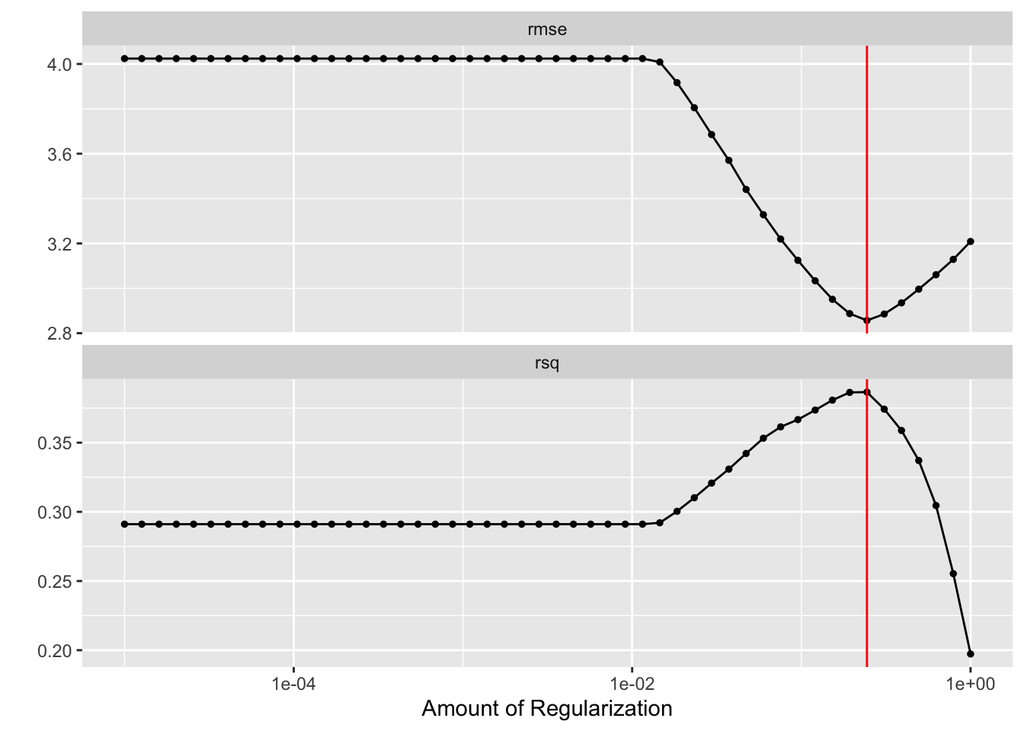

```r
tune_res %>%
  autoplot() +
  geom_vline(xintercept = 0.2442053, color = "red")
```

## 7.4 Best Hyperparameter

The best value of $\lambda$ is 0.244.

```r
best_rmse <- select_best(tune_res, metric = "rmse")
best_rmse
```

```
## # A tibble: 1 x 2
##   penalty .config
##     <dbl> <chr>
## 1   0.244 Preprocessor1_Model44
```

```r
lasso_final <- finalize_workflow(lasso_wf, best_rmse)
```

```r
lasso_final_fit <- fit(lasso_final, data = animals_train)
```

## 7.5 Peformance

Fit a lasso regression model to predict weight based on all the other variables. With the rmse value, we can conclude that the model performs mediocrity. However, we can carry out additional comparisons, such as canceling the penalty term in the model, to determine whether the good performance is due to hyperparameters or the model itself.

```r
augment(lasso_final_fit, new_data = animals_test) %>%
  rmse(truth = weight, estimate = .pred)
```

```
## # A tibble: 1 x 3
##   .metric .estimator .estimate
##   <chr>   <chr>          <dbl>
## 1 rmse    standard        2.92
```

## 7.6 Visualization

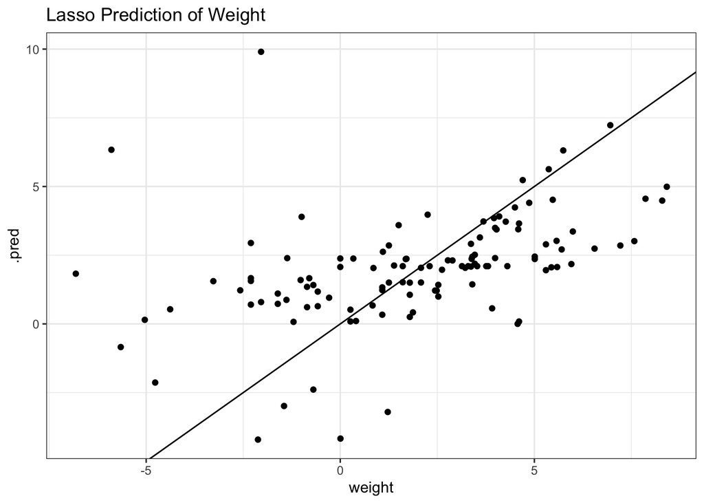

```r
augment(lasso_final_fit, new_data = animals_test) %>%
  ggplot(aes(weight, .pred)) +
  geom_abline(slope = 1, intercept = 0) +
  geom_point() +
  theme_bw() +
  ggtitle("Lasso Prediction of Weight")
```

The `weight` range is from -8.111728 to 10.491274 from the original data set, and based on the plot above, we can conclude that the model does not work well; tuning $\lambda$ appears to have no obvious benefit in the model.

```r
animals %>%
  select(weight) %>%
  range()
```

```
## [1] -8.111728 10.491274
```

# 8 References

- https://towardsdatascience.com/regularization-in-machine-learning-76441ddcf99a
- https://towardsdatascience.com/cross-validation-in-machine-learning-72924a69872f
- https://stats.idre.ucla.edu/spss/seminars/efa-spss/
- https://clauswilke.com/blog/2020/09/07/pca-tidyverse-style/
- https://medium.com/analytics-vidhya/principal-component-analysis-too-many-variables-here-73dddec6b53d
- https://youtu.be/FgakZw6K1QQ